```python
import numpy as np
import pandas as pd
from sklearn.decomposition import PCA
import seaborn as sns
import matplotlib.pyplot as plt
%matplotlib inline
```

```python
import os
os.chdir("D:\\Academic Operations\\DSBA - Python\\Online\\Advanced Statistics\\PCA\\Quiz\\5")
os.getcwd()
```

```
'D:\\Academic Operations\\DSBA - Python\\Online\\Advanced Statistics\\PCA\\Quiz\\5'
```

# Q4) Which of the variables in the dataset is not significant for doing Principal Component Analysis?

```python
df = pd.read_csv("FB.csv")
df.head()
```

|  | status_id | num_reactions | num_comments | num_shares | num_likes | num_loves | num_wows | num_hahas | num_sads | num_angrys | status_link | status_photo | status_status |
| --- | --- | --- | --- | --- | --- | --- | --- | --- | --- | --- | --- | --- | --- |
| 0 | 246675545449582_1649696485147474 | 529 | 512 | 262 | 432 | 92 | 3 | 1 | 1 | 0 | 0 | 0 | 0 |
| 1 | 246675545449582_1649426988507757 | 150 | 0 | 0 | 150 | 0 | 0 | 0 | 0 | 0 | 0 | 1 | 0 |
| 2 | 246675545449582_1648730588577397 | 227 | 236 | 57 | 204 | 21 | 1 | 1 | 0 | 0 | 0 | 0 | 0 |
| 3 | 246675545449582_1648576705259452 | 111 | 0 | 0 | 111 | 0 | 0 | 0 | 0 | 0 | 0 | 1 | 0 |
| 4 | 246675545449582_1645700502213739 | 213 | 0 | 0 | 204 | 9 | 0 | 0 | 0 | 0 | 0 | 1 | 0 |

### Now, let us go ahead and drop the column 'status_id' as that variable is of no use to us when we are doing Principal Component Analysis.

```python
df_new = df.drop(['status_id'],axis = 1)
df_new.head()
```

|  | num_reactions | num_comments | num_shares | num_likes | num_loves | num_wows | num_hahas | num_sads | num_angrys | status_link | status_photo | status_status |
| --- | --- | --- | --- | --- | --- | --- | --- | --- | --- | --- | --- | --- |
| 0 | 529 | 512 | 262 | 432 | 92 | 3 | 1 | 1 | 0 | 0 | 0 | 0 |
| 1 | 150 | 0 | 0 | 150 | 0 | 0 | 0 | 0 | 0 | 0 | 1 | 0 |
| 2 | 227 | 236 | 57 | 204 | 21 | 1 | 1 | 0 | 0 | 0 | 0 | 0 |
| 3 | 111 | 0 | 0 | 111 | 0 | 0 | 0 | 0 | 0 | 0 | 1 | 0 |
| 4 | 213 | 0 | 0 | 204 | 9 | 0 | 0 | 0 | 0 | 0 | 1 | 0 |

# Q5) After doing z-score scaling on the dataset, what is the value of the 2nd observation of the variable ‘ num_hahas’?

```python
from scipy.stats import zscore
df_new=df_new.apply(zscore)
df_new.head()
```

|  | num_reactions | num_comments | num_shares | num_likes | num_loves | num_wows | num_hahas | num_sads | num_angrys | status_link | status_photo | status_status |
| --- | --- | --- | --- | --- | --- | --- | --- | --- | --- | --- | --- | --- |
| 0 | 0.646104 | 0.323350 | 1.686879 | 0.482727 | 1.983266 | 0.196196 | 0.076713 | 0.473570 | -0.155748 | -0.094957 | -1.245993 | -0.233666 |
| 1 | -0.173192 | -0.252206 | -0.304144 | -0.144720 | -0.318454 | -0.147879 | -0.176010 | -0.152587 | -0.155748 | -0.094957 | 0.802573 | -0.233666 |
| 2 | -0.006738 | 0.013089 | 0.129017 | -0.024571 | 0.206938 | -0.033187 | 0.076713 | -0.152587 | -0.155748 | -0.094957 | -1.245993 | -0.233666 |
| 3 | -0.257499 | -0.252206 | -0.304144 | -0.231495 | -0.318454 | -0.147879 | -0.176010 | -0.152587 | -0.155748 | -0.094957 | 0.802573 | -0.233666 |
| 4 | -0.037003 | -0.252206 | -0.304144 | -0.024571 | -0.093286 | -0.147879 | -0.176010 | -0.152587 | -0.155748 | -0.094957 | 0.802573 | -0.233666 |

The value of the 2nd observation of the variable ‘ num_hahas’ is $\textbf{-0.176010}$.

# Q6) After doing z-score scaling on the dataset, which of the variables have zero or almost zero outliers ( least number of outliers)?

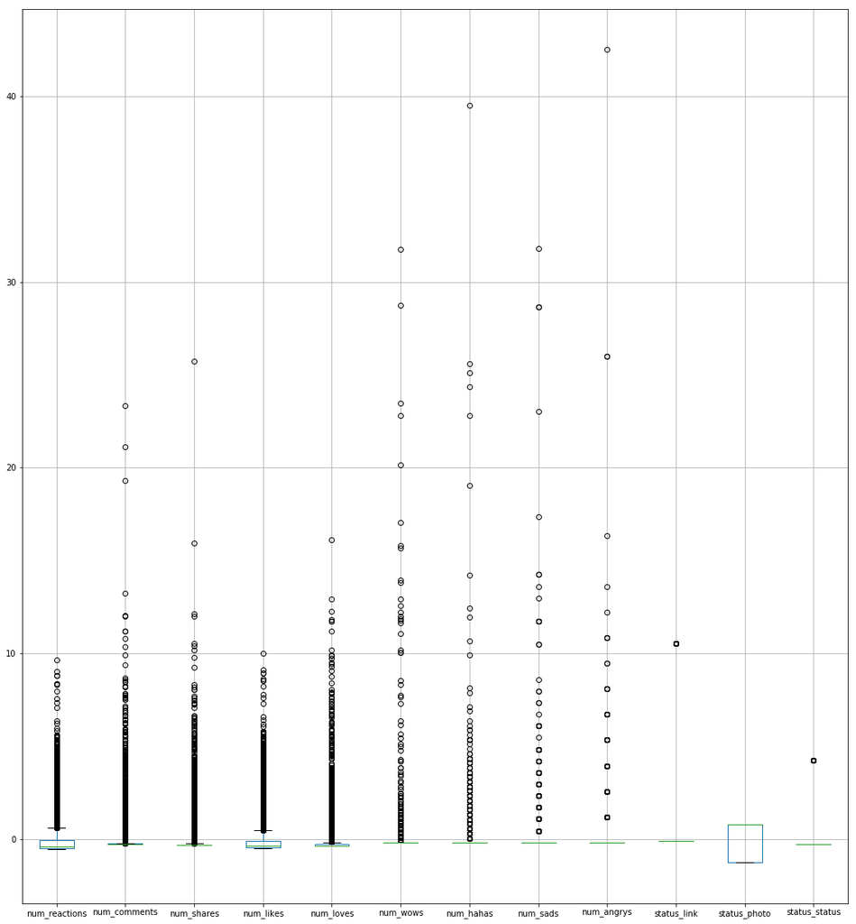

```python
df_new.boxplot(figsize=(18,20))
```

The variable to have zero or almost zero outliers (least number of outliers) is $\textbf{status_photo}$.

# Q7) After doing z-score scaling on the dataset, what is the value of the diagonal elements of the covariance matrix formed on this scaled dataset?

```python
cov_matrix = np.cov(df_new.T)
print('Covariance Matrix \n%s', cov_matrix)
```

```
Covariance Matrix
%s [[ 1.00014186  0.1508643   0.25075809  0.99506451  0.30504605  0.2677898
   0.17605301  0.07514867  0.1243437   0.02874721 -0.13153369  0.10541715]
 [ 0.1508643   1.00014186  0.64072829  0.10170146  0.52129743  0.16241703
   0.32509411  0.23648623  0.22521631 -0.02334367 -0.29188709 -0.04942026]
 [ 0.25075809  0.64072829  1.00014186  0.1725164   0.82011657  0.40768568
   0.39988229  0.19999833  0.31255689 -0.02571137 -0.35483022 -0.06653382]
 [ 0.99506451  0.10170146  0.1725164   1.00014186  0.20933778  0.20782924
   0.12080097  0.05217624  0.08744305  0.03266301 -0.10055153  0.11464773]
 [ 0.30504605  0.52129743  0.82011657  0.20933778  1.00014186  0.50887022
   0.50790168  0.20762964  0.3710539  -0.02952704 -0.35179053 -0.06529185]
 [ 0.2677898   0.16241703  0.40768568  0.20782924  0.50887022  1.00014186
   0.28779702  0.08651499  0.18311248 -0.01196935 -0.0864212  -0.00312953]
 [ 0.17605301  0.32509411  0.39988229  0.12080097  0.50790168  0.28779702
   1.00014186  0.14144092  0.21194022 -0.01595372 -0.15925947 -0.03466092]
 [ 0.07514867  0.23648623  0.19999833  0.05217624  0.20762964  0.08651499
   0.14144092  1.00014186  0.14209263 -0.01449119 -0.07896406  0.02086898]
 [ 0.1243437   0.22521631  0.31255689  0.08744305  0.3710539   0.18311248
   0.21194022  0.14209263  1.00014186 -0.01479139 -0.11571171 -0.02846925]
 [ 0.02874721 -0.02334367 -0.02571137  0.03266301 -0.02952704 -0.01196935
  -0.01595372 -0.01449119 -0.01479139  1.00014186 -0.11833196 -0.02219127]
 [-0.13153369 -0.29188709 -0.35483022 -0.10055153 -0.35179053 -0.0864212
  -0.15925947 -0.07896406 -0.11571171 -0.11833196  1.00014186 -0.2911876 ]
 [ 0.10541715 -0.04942026 -0.06653382  0.11464773 -0.06529185 -0.00312953
  -0.03466092  0.02086898 -0.02846925 -0.02219127 -0.2911876   1.00014186]]
```

After running the above code snippet, we can thus see that the value of the diagonal elements of the covariance matrix built on this dataset is $\textbf{1}$.

# Q8) What is the eigen value associated with the first variable?

```python
eig_vals, eig_vecs = np.linalg.eig(cov_matrix)
print('Eigen Vectors \n%s', eig_vecs)
print('\n Eigen Values \n%s', eig_vals)
```

```
Eigen Vectors
%s [[ 2.93630543e-01  6.06641137e-01  7.15773171e-01  2.03910032e-02
  -1.12002407e-01  4.82435866e-03  3.20850086e-02  2.42016415e-02
  -6.97861393e-02  8.52072210e-02  8.18911389e-02 -1.04601450e-03]
 [ 3.47497866e-01 -2.30746002e-01 -1.26384681e-06  1.67785969e-01
   8.75480006e-02 -5.17376834e-01 -5.15597556e-01 -3.99866919e-02
  -1.69312690e-01  4.37540439e-01  1.86287704e-01  1.59573424e-02]
 [ 4.43254435e-01 -2.04910484e-01  1.73179788e-05 -6.71346886e-01
   3.92859022e-03  4.57024584e-01 -1.12734594e-01 -2.04542894e-01
  -5.09397191e-02  1.96740735e-01 -6.98659821e-02 -3.48387949e-02]
 [ 2.51769604e-01  6.40653903e-01 -6.95423734e-01 -3.90502026e-02
  -1.05702016e-01 -2.79737958e-02  2.54206909e-02  3.28768718e-02
  -8.70489869e-02  9.66955499e-02  1.02090297e-01  1.73807760e-03]
 [ 4.61255079e-01 -1.65917245e-01 -6.18696218e-02  7.03643043e-01
  -5.18155502e-02  4.72074756e-01  7.92827429e-02 -8.44140094e-02
   3.53002915e-02  4.86999544e-03 -1.39427366e-01 -3.33633828e-02]
 [ 2.96340391e-01  1.62620307e-02 -1.34885816e-02 -7.08473070e-02
  -2.11548727e-01 -4.17684976e-01 -2.93540341e-02 -4.07729726e-01
   4.88194788e-01 -3.72249407e-01 -3.77299473e-01 -3.37517224e-02]
 [ 3.08854346e-01 -1.39033435e-01 -6.11926720e-03 -1.19364205e-01
  -1.01800997e-01 -9.89072403e-02  6.43937564e-02  8.72041584e-01
   2.54094006e-01 -5.77002760e-02 -1.34291828e-01 -1.78014533e-02]
 [ 1.63130579e-01 -1.10415493e-01 -2.46986519e-03 -2.15417600e-02
   4.98793399e-02  2.79589183e-02  1.61485163e-01 -8.01933929e-02
   4.06107733e-01 -1.73120550e-01  8.16405043e-01  2.52065840e-01]
 [ 2.37246758e-01 -1.26874184e-01 -1.12235269e-03 -4.90180785e-02
  -8.92316571e-02 -1.08786107e-01 -1.31307099e-02  3.56999871e-02
  -6.61974694e-01 -6.69842952e-01  1.23557407e-01  4.24590001e-02]
 [-1.38340912e-03  6.41854579e-02  2.77128984e-08  1.08316035e-02
   2.35213036e-01  6.50090460e-02 -2.07490740e-01  2.77449796e-02
   1.24037696e-01 -1.90214360e-01  2.09968130e-01 -8.92599564e-01]
 [-2.32613706e-01  3.65506390e-02 -2.10860170e-06  3.74449557e-02
  -6.43419111e-01  2.64740805e-01 -6.39131228e-01  7.27513701e-02
   1.14406851e-01 -1.20870465e-01  1.11485989e-01  7.18869432e-02]
 [ 1.37973532e-02  2.13188742e-01  1.59933119e-07  2.08221545e-02
   6.56534644e-01  1.69162607e-01 -4.80301401e-01  8.54568120e-02
   1.43312376e-01 -2.86124118e-01 -1.58614319e-01  3.58771030e-01]]

 Eigen Values
%s [3.59628800e+00 1.78479109e+00 1.64801523e-08 1.48486541e-01
 1.25112250e+00 3.58889859e-01 5.28735394e-01 6.95632348e-01
 8.11985438e-01 8.49591639e-01 9.55282786e-01 1.02089676e+00]
```

# Q9) What is the cumulative variance explained by the last variable or cumulatively taking the last variable into account?

```python
tot = sum(eig_vals)
var_exp = [( i /tot ) * 100 for i in sorted(eig_vals, reverse=True)]
cum_var_exp = np.cumsum(var_exp)
print("Cumulative Variance Explained", cum_var_exp)
```

```
Cumulative Variance Explained [ 29.96481572  44.83596514  55.26050708  63.76677335  71.72633406
  78.80526014  85.57084566  91.36695963  95.77246293  98.76278754
  99.99999986 100.        ]
```

From the above code snippet, we can see that the cumulative variance explained by the last variable is $\textbf{100%}$.

# Q10) What is the Y-Axis (or what is the variable on the Y-axis) when we are plotting the scree plot?

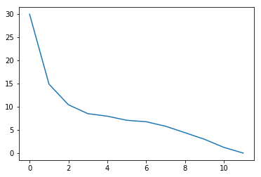

```python
plt.plot(var_exp)
```

$\textbf{Y-Axis denotes the variance explained by a particular variable.}$

Let us go ahead and run the codes of Principal Component Analysis.

```python
# Using scikit learn PCA here. It does all the above steps and maps data to PCA dimensions in one shot
from sklearn.decomposition import PCA

# NOTE - we are generating only 9 PCA dimensions (dimensionality reduction from 12 to 9)

pca = PCA(n_components=9)
data_reduced = pca.fit_transform(df_new)
data_reduced.transpose()
```

```
array([[ 2.49500294, -0.80644199,  0.38778102, ..., -0.97231247,
        -0.46550736, -0.96536827],
       [-0.18957102,  0.00767383, -0.15966981, ..., -0.40295527,
         0.50925543, -0.35632615],
       [-0.42293659,  0.60872631, -0.62573078, ...,  0.53914638,
         0.70494912,  0.54524478],
       ...,
       [-0.06510389, -0.04240942,  0.14226483, ..., -0.09447845,
         0.03549011, -0.08823347],
       [-0.66376289,  0.03949637, -0.07149823, ...,  0.01874201,
         0.02560935,  0.02280911],
       [-0.83933813,  0.28076431, -0.90587656, ...,  0.29747346,
         0.27740319,  0.29751165]])
```

```python
pca.components_
```

```
array([[ 0.29363054,  0.34749787,  0.44325444,  0.2517696 ,  0.46125508,
         0.29634039,  0.30885435,  0.16313058,  0.23724676, -0.00138341,
        -0.23261371,  0.01379735],
       [ 0.60664114, -0.230746  , -0.20491048,  0.6406539 , -0.16591724,
         0.01626203, -0.13903343, -0.11041549, -0.12687418,  0.06418546,
         0.03655064,  0.21318874],
       [ 0.11200241, -0.087548  , -0.00392859,  0.10570202,  0.05181555,
         0.21154873,  0.101801  , -0.04987934,  0.08923166, -0.23521304,
         0.64341911, -0.65653464],
       [ 0.00104601, -0.01595734,  0.03483879, -0.00173808,  0.03336338,
         0.03375172,  0.01780145, -0.25206584, -0.042459  ,  0.89259956,
        -0.07188694, -0.35877103],
       [ 0.08189114,  0.1862877 , -0.06986598,  0.1020903 , -0.13942737,
        -0.37729947, -0.13429183,  0.81640504,  0.12355741,  0.20996813,
         0.11148599, -0.15861432],
       [-0.08520722, -0.43754044, -0.19674073, -0.09669555, -0.00487   ,
         0.37224941,  0.05770028,  0.17312055,  0.66984295,  0.19021436,
         0.12087046,  0.28612412],
       [ 0.06978614,  0.16931269,  0.05093972,  0.08704899, -0.03530029,
        -0.48819479, -0.25409401, -0.40610773,  0.66197469, -0.1240377 ,
        -0.11440685, -0.14331238],
       [ 0.02420164, -0.03998669, -0.20454289,  0.03287687, -0.08441401,
        -0.40772973,  0.87204158, -0.08019339,  0.03569999,  0.02774498,
         0.07275137,  0.08545681],
       [-0.03208501,  0.51559756,  0.11273459, -0.02542069, -0.07928274,
         0.02935403, -0.06439376, -0.16148516,  0.01313071,  0.20749074,
         0.63913123,  0.4803014 ]])
```

```python
df_comp = pd.DataFrame(pca.components_,columns=list(df_new))
df_comp.head()
```

|  | num_reactions | num_comments | num_shares | num_likes | num_loves | num_wows | num_hahas | num_sads | num_angrys | status_link | status_photo | status_status |
| --- | --- | --- | --- | --- | --- | --- | --- | --- | --- | --- | --- | --- |
| 0 | 0.293631 | 0.347498 | 0.443254 | 0.251770 | 0.461255 | 0.296340 | 0.308854 | 0.163131 | 0.237247 | -0.001383 | -0.232614 | 0.013797 |
| 1 | 0.606641 | -0.230746 | -0.204910 | 0.640654 | -0.165917 | 0.016262 | -0.139033 | -0.110415 | -0.126874 | 0.064185 | 0.036551 | 0.213189 |
| 2 | 0.112002 | -0.087548 | -0.003929 | 0.105702 | 0.051816 | 0.211549 | 0.101801 | -0.049879 | 0.089232 | -0.235213 | 0.643419 | -0.656535 |
| 3 | 0.001046 | -0.015957 | 0.034839 | -0.001738 | 0.033363 | 0.033752 | 0.017801 | -0.252066 | -0.042459 | 0.892600 | -0.071887 | -0.358771 |
| 4 | 0.081891 | 0.186288 | -0.069866 | 0.102090 | -0.139427 | -0.377299 | -0.134292 | 0.816405 | 0.123557 | 0.209968 | 0.111486 | -0.158614 |